# Project 1

Matt Fein, Jeffrey Jou, Polly McKim, Pancea Motawi, and Elise Roberts

October 14, 2019

# Chapter 1: Introduction

Founded in 2008, Airbnb bills itself as an online marketplace for renting or listing accommodations in cities around the world. While the company has recently started listing tourism experiences in addition to available lodgings, most of the company’s revenue is generated by connecting people who want to rent a lodging with those who have a spare lodging available. Airbnb boasted a valuation of $31 billion in 2017, and reported a revenue of $2.5 billion for 2017, the last full year for which Airbnb has released data. Recent quarterly specific revenues released by the company exceed $1 billion. Airbnb emphasizes that its platform provides travelers with a more cost effective and “local” way to travel while giving “hosts” the opportunity to earn additional income. In Washington, DC, Airbnb hosts earned a reported $96 million from hosting on the site in 2018. This project explores data Airbnb listings in Washington, DC published on July 15, 2019 from Inside Airbnb, and independent, non-commercial set of data that allows users to explore how Airbnb is really being used in cities around the world. We analyzed data related to room type offered, neighborhoods where Airbnb’s were located, room price, and use the number of reviews as a proxy variable for popularity. From a consumer perspective, we would like to discover the interactions between price and popularity, price and room type, price and neighborhood, popularity and neighborhood, as well as room type and neighborhood, in order to book the most cost-effective, popular room in the best neighborhood.

# Chapter 2: Description of Data

## 2.1 Source Data

The data for this project is from InsideAirbnb.com. This website contains information sourced by Murray Cox, who utilized Airbnb’s public application programming interface (API) to mine this data. Originally, Cox scraped this data to identify illegal listings in New York City. He has since expanded his data set offerings to cities across the world and makes this datum available for open source use and research.

Although Cox is potentially a biased source, due to his activist leanings, his datasets originate from Airbnb themselves and are thoroughly documented. We also considered using data from Airbnb directly, however, other studies have shown that this data is outdated and biased in that it only shows the positive side of Airbnb. Mr. Cox, however, seeks to use the company’s own data is that he scraped from the website itself through a well-documented procedure to explore how Airbnb is really affecting our community. Therefore, we decided that the dataset was reliable because of the author’s documentation and his purpose for releasing it.

```
## 'data.frame':    9126 obs. of  16 variables:
##  $ id                            : int  3344 3362 3662 3670 3686 3771 4197 4501 4529 4967 ...
##  $ name                          : Factor w/ 9025 levels ""," Private Junior Suite",..: 8950 2798 8761 1345 8760 6036 1421 3493 1434 3510 ...
##  $ host_id                       : int  4957 2798 4645 4630 4645 4795 5061 1585 5803 7086 ...
##  $ host_name                     : Factor w/ 2810 levels "","'Twee'","(Email hidden by Airbnb)",..: 9 253 2698 2382 2698 476 2288 1445 311 2341 ...
##  $ neighbourhood_group           : logi  NA NA NA NA NA NA ...
##  $ neighbourhood                 : Factor w/ 39 levels "Brightwood Park, Crestwood, Petworth",..: 12 30 20 21 20 8 3 30 14 22 ...
##  $ latitude                      : num  38.9 38.9 38.9 38.9 38.9 ...
##  $ longitude                     : num  -77 -77 -77 -77 -77 ...
##  $ room_type                     : Factor w/ 3 levels "Entire home/apt",..: 2 1 2 2 2 2 2 2 2 2 ...
##  $ price                         : int  48 433 65 75 55 88 83 475 65 99 ...
##  $ minimum_nights                : int  306 2 2 2 2 1 60 2 5 2 ...
##  $ number_of_reviews             : int  11 165 36 79 70 1 41 120 102 31 ...
##  $ last_review                   : Factor w/ 1050 levels "","2009-01-21",..: 263 1036 961 725 993 2 1008 71 1041 276 ...
##  $ reviews_per_month             : num  0.09 1.29 0.36 1.5 0.66 0.01 0.33 0.94 0.84 0.29 ...
##  $ calculated_host_listings_count: int  2 5 3 1 3 1 2 1 2 3 ...
##  $ availability_365              : int  363 321 274 365 235 0 87 0 179 181 ...
```

```
## [1] 446
```

The variables included in this dataset include:  
- Airbnb ID Number  
- Listing Name  
- Host ID Number  
- Neighborhood  
- Latitude  
- Longitude  
- Room Type  
- Price  
- Minimum Nights  
- Number of Reviews  
- Last Review Date  
- Reviews per Month  
- Calculated Host Listings  
- Availability 365 Days a Year

# Chapter 3: Exploratory Data Analysis

## 3.1 Do the number of reviews differ by room type?

> outlierKD(listing, price)  
> outlierKD(listing, number_of_reviews)

First, we removed any outliers in the number of reviews variable of the dataset using the outlierKD function courtesy of Dr. Lo. Then we explore the data through basic charts, starting with a boxplot of the number of reviews grouped by room type. The variable “room_type” is a factor variable with 3 levels: Entire home/apt, private room, and shared room.

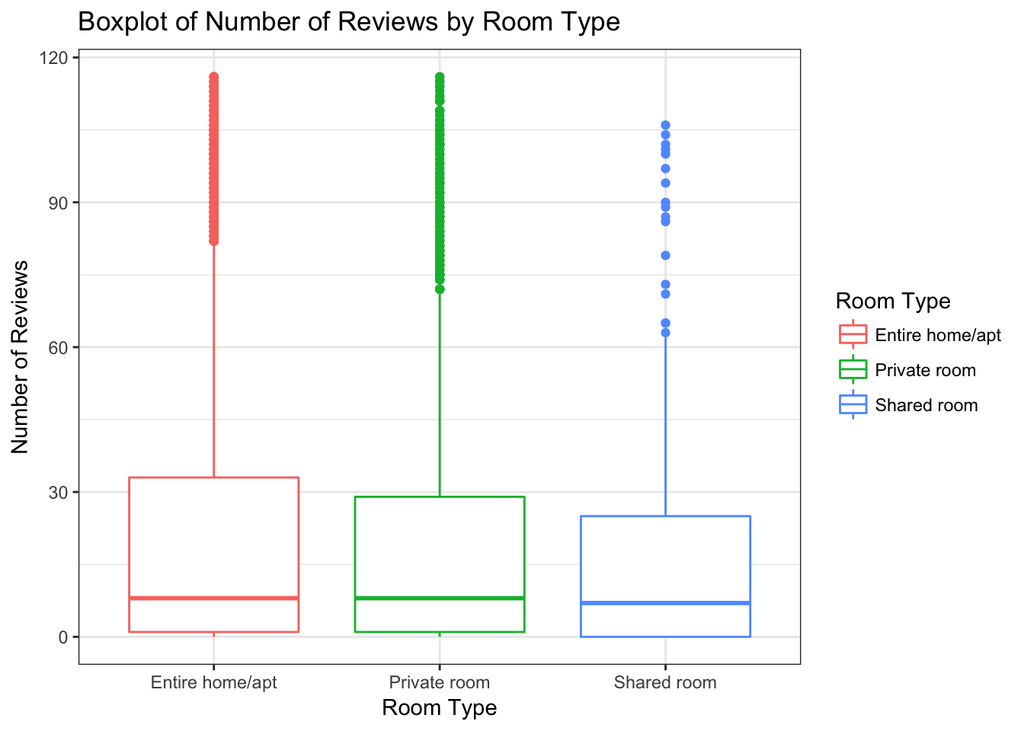

As you can see from the boxplots above, the means and interquartile ranges of the three room types plotted against number of reviews differ marginally. The number of reviews for entire homes seems to be slightly higher than that of the shared rooms.

Analysis of Variance Model

|  | Df | Sum Sq | Mean Sq | F value | Pr(>F) |
| --- | --- | --- | --- | --- | --- |
| **as.factor(room_type)** | 2 | 6273 | 3136 | 3.91 | 0.02007 |
| **Residuals** | 8256 | 6622140 | 802.1 | NA | NA |

```
##   Tukey multiple comparisons of means
##     95% family-wise confidence level
##
## Fit: aov(formula = number_of_reviews ~ as.factor(room_type), data = listing)
##
## $`as.factor(room_type)`
##                                   diff       lwr        upr     p adj
## Private room-Entire home/apt -1.612514 -3.289230 0.06420195 0.0624811
## Shared room-Entire home/apt  -3.651948 -8.240735 0.93683883 0.1488442
## Shared room-Private room     -2.039434 -6.769794 2.69092612 0.5701338
```

## 3.2 Does the price of a room differ by room type?

To begin, we start with another visualization of price by room type using another boxplot.

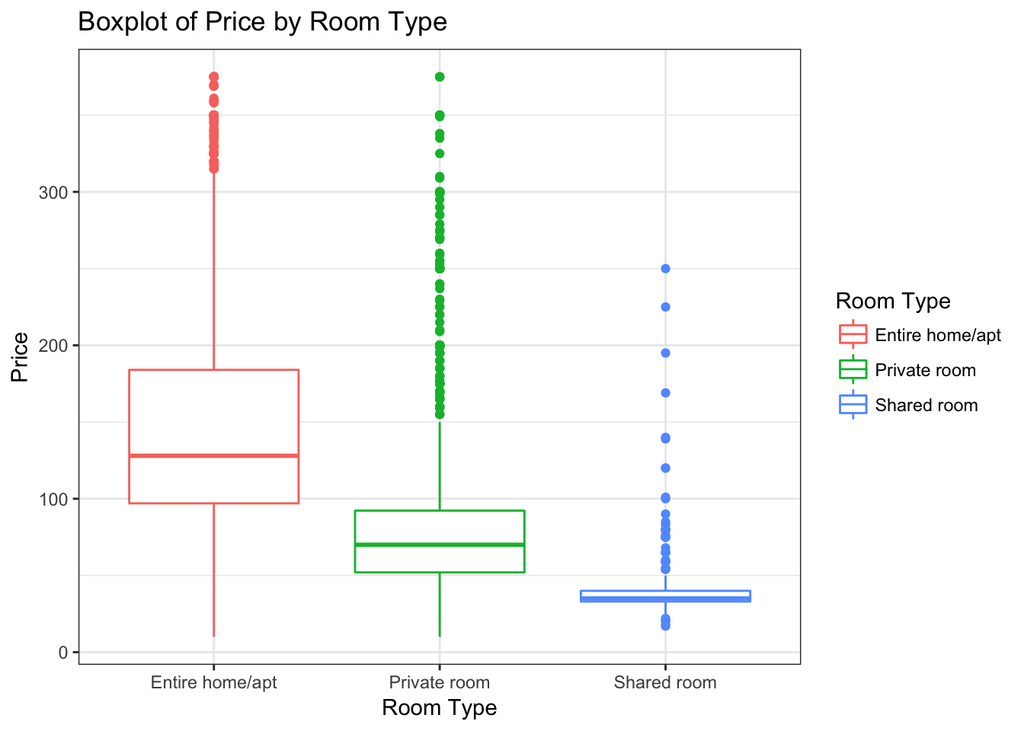

The boxplot clearly demonstrates a dramatic difference in the mean price by room type. It is important to note that none of the means are even within the interquartile range of the room type, as all of them are so vastly distinct from the other.

Analysis of Variance Model

|  | Df | Sum Sq | Mean Sq | F value | Pr(>F) |
| --- | --- | --- | --- | --- | --- |
| **as.factor(room_type)** | 2 | 8457833 | 4228916 | 987.9 | 0 |
| **Residuals** | 8204 | 35117321 | 4281 | NA | NA |

```
##   Tukey multiple comparisons of means
##     95% family-wise confidence level
##
## Fit: aov(formula = price ~ as.factor(room_type), data = listing)
##
## $`as.factor(room_type)`
##                                    diff        lwr       upr p adj
## Private room-Entire home/apt  -64.86287  -68.65482 -61.07092     0
## Shared room-Entire home/apt  -104.06094 -114.55310 -93.56878     0
## Shared room-Private room      -39.19807  -49.97747 -28.41868     0
```

The above ANOVA tests confirms that the mean price differs by room type with a p-value of zero, which is the most statistically significant result possible. Additionally, when mean prices by room type are compared by each other, all of the p-values for these interactions are zero as well. Therefore, we reject the null hypothesis that the mean prices are the same by room type.

## 3.3 How do prices differ by neighborhood?

The following displays three separate maps, colored by rate per night. The first map displays all properties regardless of type of Airbnb (room or apartment). The second map displays only rooms for rent, and the third is for entire apartments available on Airbnb.

[interactive chart not shown]

[figure not shown]

The bar chart above demonstrates the number of Airbnb listings in each of the top 15 neighborhoods in Washington, D.C. The neighborhoods with the highest concentration of Airbnb listings are Mt. Pleasant, Pleasant Plains, and Columbia Heights - which are all mostly residential neighborhoods in D.C.

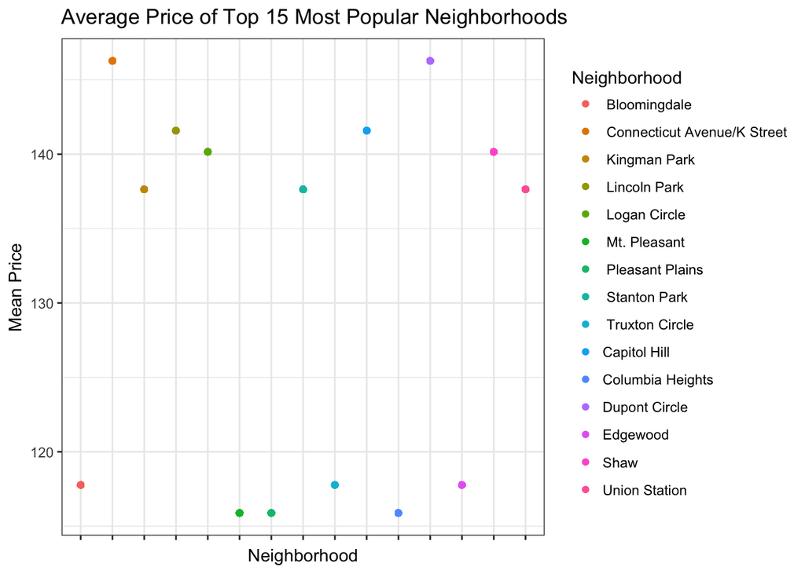

The above scatterplot shows the distribution of mean price by neighborhood. As you can see, there is a large gap between the lowest priced neighborhoods and higher priced neighborhoods. The lowest priced neighborhoods include Bloomingdale, Mt. Pleasant, Pleasant Plains, Truxton Circle, Columbia Heights, and Edgewood.

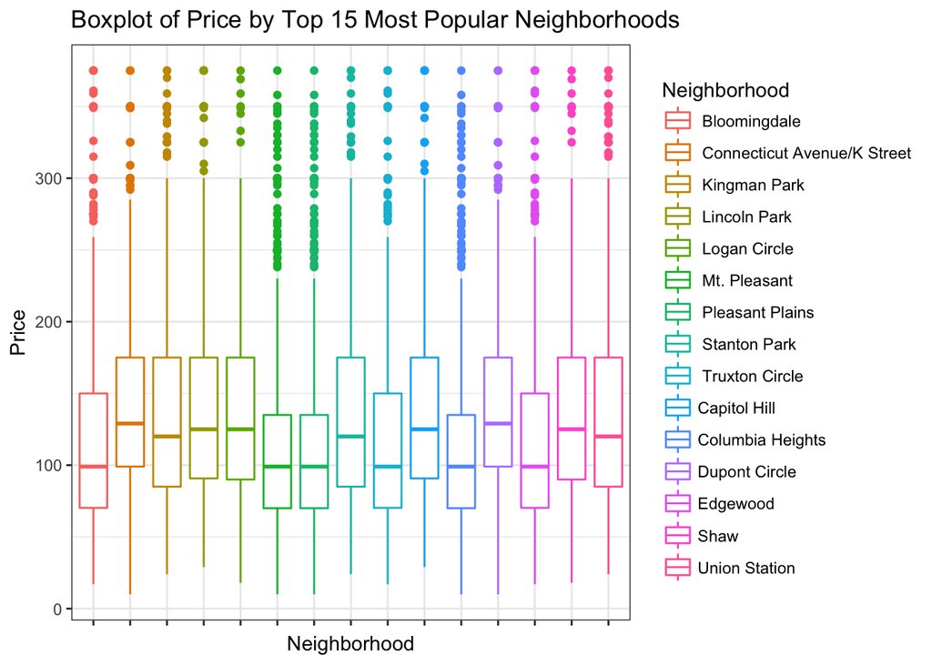

The boxplot above demonstrates the distribution of prices by the top 15 neighborhoods. Based on this visualization, it is clear that the mean price varies greatly between some neighborhoods, while other neighborhoods seem to be nearly identical.

Analysis of Variance Model

|  | Df | Sum Sq | Mean Sq | F value | Pr(>F) |
| --- | --- | --- | --- | --- | --- |
| **as.factor(neighborhood)** | 14 | 1585797 | 113271 | 22.35 | 1.963e-57 |
| **Residuals** | 10666 | 54063217 | 5069 | NA | NA |

```
##   Tukey multiple comparisons of means
##     95% family-wise confidence level
##
## Fit: aov(formula = price ~ as.factor(neighborhood), data = price_table)
##
## $`as.factor(neighborhood)`
##                                                        diff        lwr
##  Connecticut Avenue/K Street- Bloomingdale     2.849625e+01  15.246765
##  Kingman Park- Bloomingdale                    1.986502e+01   7.048013
##  Lincoln Park- Bloomingdale                    2.381145e+01  10.838176
##  Logan Circle- Bloomingdale                    2.238602e+01   8.384690
##  Mt. Pleasant- Bloomingdale                   -1.882028e+00 -14.474155
##  Pleasant Plains- Bloomingdale                -1.882028e+00 -14.474155
##  Stanton Park- Bloomingdale                    1.986502e+01   7.048013
##  Truxton Circle- Bloomingdale                 -1.151079e-12 -13.314128
## Capitol Hill- Bloomingdale                     2.381145e+01  10.838176
## Columbia Heights- Bloomingdale                -1.882028e+00 -14.474155
## Dupont Circle- Bloomingdale                    2.849625e+01  15.246765
## Edgewood- Bloomingdale                         3.836931e-13 -13.314128
## Shaw- Bloomingdale                             2.238602e+01   8.384690
## Union Station- Bloomingdale                    1.986502e+01   7.048013
##  Kingman Park- Connecticut Avenue/K Street    -8.631228e+00 -21.381072
##  Lincoln Park- Connecticut Avenue/K Street    -4.684799e+00 -17.591722
##  Logan Circle- Connecticut Avenue/K Street    -6.110228e+00 -20.050102
##  Mt. Pleasant- Connecticut Avenue/K Street    -3.037828e+01 -42.902034
##  Pleasant Plains- Connecticut Avenue/K Street -3.037828e+01 -42.902034
##  Stanton Park- Connecticut Avenue/K Street    -8.631228e+00 -21.381072
##  Truxton Circle- Connecticut Avenue/K Street  -2.849625e+01 -41.745733
## Capitol Hill- Connecticut Avenue/K Street     -4.684799e+00 -17.591722
## Columbia Heights- Connecticut Avenue/K Street -3.037828e+01 -42.902034
## Dupont Circle- Connecticut Avenue/K Street     1.875833e-12 -13.184523
## Edgewood- Connecticut Avenue/K Street         -2.849625e+01 -41.745733
## Shaw- Connecticut Avenue/K Street             -6.110228e+00 -20.050102
## Union Station- Connecticut Avenue/K Street    -8.631228e+00 -21.381072
##  Lincoln Park- Kingman Park                    3.946429e+00  -8.516136
##  Logan Circle- Kingman Park                    2.520999e+00 -11.008485
##  Mt. Pleasant- Kingman Park                   -2.174705e+01 -33.812345
##  Pleasant Plains- Kingman Park                -2.174705e+01 -33.812345
##  Stanton Park- Kingman Park                    2.188472e-12 -12.299813
##  Truxton Circle- Kingman Park                 -1.986502e+01 -32.682030
```

[output cut: 163 more lines]

```
## Columbia Heights-Capitol Hill                 -13.462308 0.0000000
## Dupont Circle-Capitol Hill                     17.591722 0.9964989
## Edgewood-Capitol Hill                         -10.838176 0.0000001
## Shaw-Capitol Hill                              12.252184 1.0000000
## Union Station-Capitol Hill                      8.516136 0.9991960
## Dupont Circle-Columbia Heights                 42.902034 0.0000000
## Edgewood-Columbia Heights                      14.474155 0.9999999
## Shaw-Columbia Heights                          37.584690 0.0000001
## Union Station-Columbia Heights                 33.812345 0.0000001
## Edgewood-Dupont Circle                        -15.246765 0.0000000
## Shaw-Dupont Circle                              7.829646 0.9782386
## Union Station-Dupont Circle                     4.118616 0.5933395
## Shaw-Edgewood                                  36.387352 0.0000062
## Union Station-Edgewood                         32.682030 0.0000153
## Union Station-Shaw                             11.008485 0.9999988
```

Based on the results of the ANOVA test between mean prices and the top 15 neighborhoods, we got a statistically significant p-value of 1.963e-57. Therefore, we reject the null hypothesis that the mean prices for each of the top 15 neighborhoods are the same.

## 3.4 How does the number of reviews affect price?

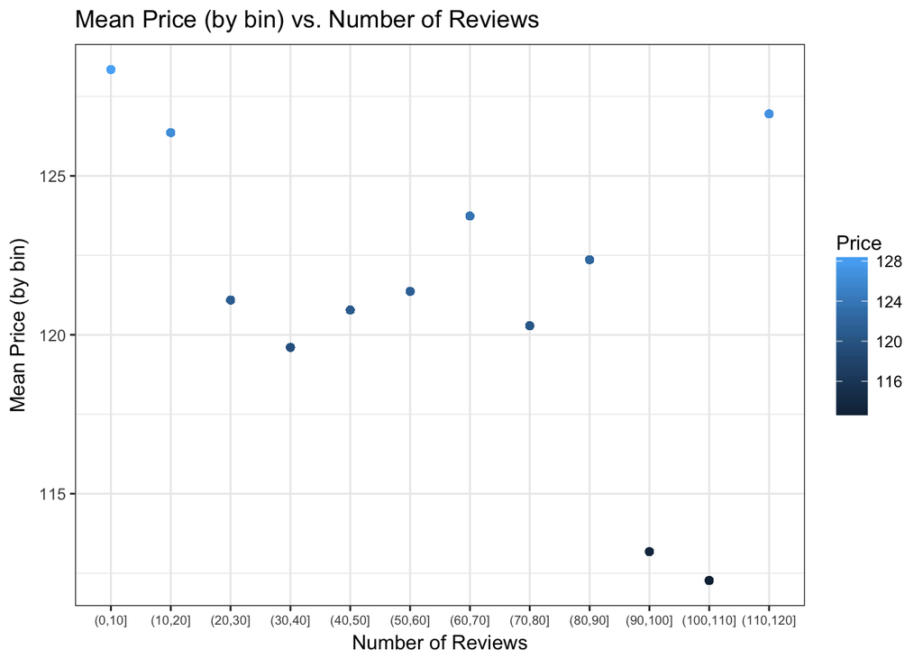

```
## [1] NA
```

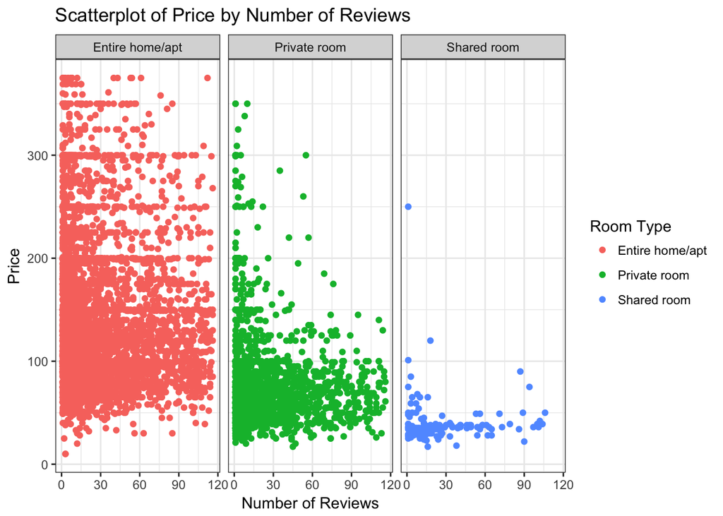

Given the inconclusive results of the last scatterplot, we considered that given our previous tests found such a strong relationship between room type and price, this could have an impact on the number of reviews. Therefore, we chose to extend our analysis further by segmenting our data by the three room types for this scatterplot of number of reviews by price. In this new scatterplot, it is clear that the shared room room type has a vastly different distribution of price by number of reviews than the entire home/apartment room type.

Taking our analysis of price and number of reviews one more step further, we ran an ANOVA test for price, binning the number of reviews by the following strata: 0 - 150 151 - 300 301 - 450 451 - 600 601 - 750

In binning the number of reviews, we compared the mean prices of the least popular listings with the most popular listings. As a result, we got the statistically significant p-value of 6.27e-05. Therefore, we reject the null hypothesis that there is no difference in means of these five bins of number of reviews. However, when we compared each bin of number of reviews by the other, to see if there is a difference between the least popular and most popular listings, the only statistically significant mean prices were between 151 - 300 and 0 - 150 as well as 301 - 450 and 0 - 150. These results are surprising, as there was no statistically significant difference in the mean prices of the most popular and least popular Airbnb listings as we had initially thought.

[figure not shown]

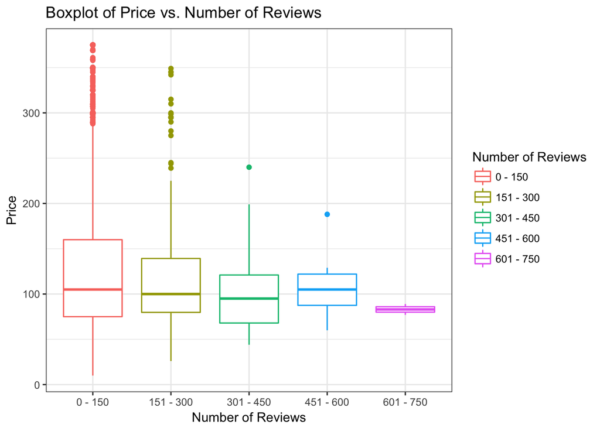

|  | Df | Sum Sq | Mean Sq | F value | Pr(>F) |
| --- | --- | --- | --- | --- | --- |
| **as.factor(number_of_reviews)** | 4 | 130081 | 32520 | 6.139 | 6.27e-05 |

Table: Analysis of Variance Model

```
##   Tukey multiple comparisons of means
##     95% family-wise confidence level
##
## Fit: aov(formula = price ~ as.factor(number_of_reviews), data = dataa)
##
## $`as.factor(number_of_reviews)`
##                           diff        lwr        upr     p adj
## 151 - 300-0 - 150   -11.686743  -21.06693  -2.306558 0.0061108
## 301 - 450-0 - 150   -31.496821  -55.86204  -7.131597 0.0038686
## 451 - 600-0 - 150   -17.554390  -92.64143  57.532645 0.9688880
## 601 - 750-0 - 150   -44.840105 -185.26924  95.589034 0.9074996
## 301 - 450-151 - 300 -19.810078  -45.72050   6.100347 0.2261435
## 451 - 600-151 - 300  -5.867647  -81.47022  69.734925 0.9995538
## 601 - 750-151 - 300 -33.153361 -173.85883 107.552107 0.9679926
## 451 - 600-301 - 450  13.942431  -64.93358  92.818442 0.9889916
## 601 - 750-301 - 450 -13.343284 -155.83435 129.147787 0.9990633
## 601 - 750-451 - 600 -27.285714 -186.49659 131.925164 0.9902100
```

Welch Two Sample t-test: `smaller375$price` and `greater375$price`

| Test statistic | df | P value | Alternative hypothesis | mean of x | mean of y |
| --- | --- | --- | --- | --- | --- |
| 1.811 | 8.067 | 0.1074 | two.sided | 126.9 | 104.2 |

## 3.5 Are room types independent of neighborhoods?

[output not shown]

```
##
##  Pearson's Chi-squared test
##
## data:  table
## X-squared = 699.67, df = 76, p-value < 2.2e-16
```